# NBA Salary Linear Regression

Kuan-I Lu, brian901231@gmail.com

2024-04-25

## Introduction

### Inspiration

Playing as a professional basketball player in the NBA is one of the all-time highest paying job, big-firms-owned teams have a huge capital dedicated to recruit and award some of the best talents in the world. But how much exactly do they make? This project we’re exploring the relationship between NBA players’ salary with some potential predictors, using the tool of linear regression models. Also, due to the large and complicated nature of sports data set, this project is also to showcase my data tidying ability to see how I can navigate my way through tedious data across decades.

I believe there must exist some indicators that has relation with NBA player salaries. Some player makes tens of millions a year , while some of the more “unlucky” ones make some hundred thousands a year (I know, it’s still alot). According to my knowledge form watching years of basketball and basic knowledge of economics, I have concludes three predictors that potentially have correlation to an NBA players salary, which is year/season they play in, the market size of the city of the team they play for, and their on-court performance.

To break these three component apart, the year takes a numeric value, indicating the calender year when the season starts (that’s pretty intuitive). The city size takes discrete variable, taking values from “big”, “medium”, and “small”, for example, the Los Angeles Lakers ,located in Los Angeles, would be a “big” city, and the Memphis Grizzlies, located in Memphis, would be a “small city”. Finally, the player’s on-court performance, this is the most complicated variable since there is numerous statistics to determine if a player is a “good” player or not, the offensive attribute tend to reflect more directly in statistics, while leadership quality and defensive ability doesn’t reflect in stats sheet as well. Therefore, I chose two indicators that represents a player’s performance to cover these two aspects, which are their points per game average for the past three years, and their net rating for the past three years. The reason why I want to take the average from the past three years is because a players salary this year is heavily depend on their past performances, generally you have to “prove” that you’re a good player before yo sign a big contract. The details of these statistic will be provided in the following sections.

### Data Description and Sources

First we load the data set and check its quality. I’ve gathered three datasets from two different sources:

- **Kaggle, NBA Players Performance and Salaries, The Devastator**

  This dataset provides a comprehensive look at NBA player salaries and performance from 1985 to 2018. It contains two data frames with detailed records of salary figures, season information, physical attributes (such as height and weight), draft information, college attended, career stats (including points scored and win shares) and shooting hand preference. From this data set, I will be utilizing the salaries, player name, years played, and team information. [link here](https://www.kaggle.com/datasets/thedevastator/exploring-nba-player-performance-and-salaries-19?rvi=1)
- **Kaggle, NBA Players, Justina Cirtautas**

  The data set on Kaggle contains over two decades of data on each player who has been part of an NBA teams’ roster, with the time frame spanning from 1996-2022. It captures demographic variables such as age, height, weight and place of birth, biographical details like the team played for, draft year and round. In addition, it has basic box score statistics such as games played, average number of points, rebounds, assists, etc. From this data set I will be taking the players’ name, team, ppg and +/- for each year. Also since this data set’s time frame doesn’t perfectly overlap with *NBA Players Performance and Salaries*, I will be investigating the time period where two data sets overlaps, which is from 1996-2018. [link here](https://www.kaggle.com/datasets/justinas/nba-players-data?rvi=1)
- **HoopSocials.com, NBA Team Market Size Rankings, Michael Burns**

  This is not a data set, but works as an additional source to help classify teams sizes into categories *big*, *medium*, and *small*. HoopsSocials.com is a media platform focusing on sports news and collecting sports data, specifically in basketball and about leagues like NBA and WNBA. I will be using the classification provided in this website to help me determine and classify the scale of an NBA team, as I believe that the market size of an NBA team will be an effective predictor of an NBA player’s salary. Additionally, since the website only covers cities that currently has NBA teams, for those city in the data frame that previously have NBA teams, I will refer to [this page](https://www.sportsmediawatch.com/nba-market-size-nfl-mlb-nhl-nielsen-ratings/) from sportsmedia.com and put them in the category where their market size matches the best. [link here](https://hoop-social.com/nba-team-market-size-rankings/)

## Data Cleaning and Tidying

```r
#loading the data sets
library(tidyverse)
library(tidymodels)
library(ggplot2)
library(dplyr)
library(corrplot)
library(finalfit)
library(patchwork)

player_info_full = read.csv("C:/D/homework/linear regression project/nba player personal '96-'22/all_seasons.csv")
salary_player_info_full = read.csv("C:/D/homework/linear regression project/nba salary '85-'18/players.csv")
salary_salary_full = read.csv("C:/D/homework/linear regression project/nba salary '85-'18/salaries_1985to2018.csv")

#create a vector with all the team names matching with their abbreviations
team_abbreviations = c("Atlanta Hawks" = "ATL",
                       "Boston Celtics" = "BOS",
                       "Charlotte Bobcats" = "CHA",
                       "Charlotte Hornets" = "CHA",
                       "Chicago Bulls" = "CHI",
                       "Cleveland Cavaliers" = "CLE",
                       "Dallas Mavericks" = "DAL",
                       "Denver Nuggets" = "DEN",
                       "Detroit Pistons" = "DET",
                       "Golden State Warriors" = "GSW",
                       "Houston Rockets" = "HOU",
                       "Indiana Pacers" = "IND",
                       "Los Angeles Clippers" = "LAC",
                       "Los Angeles Lakers" = "LAL",
                       "Memphis Grizzlies" = "MEM",
                       "Miami Heat" = "MIA",
                       "Milwaukee Bucks" = "MIL",
                       "Minnesota Timberwolves" = "MIN",
                       "New Jersey Nets" = "NJN",
                       "New Orleans Pelicans" = "NOP",
                       "New Orleans Hornets" = "NOH",
                       "New Orleans/Oklahoma City Hornets" = "NOK",
                       "New York Knicks" = "NYK",
                       "Brooklyn Nets" = "BKN",
                       "Oklahoma City Thunder" = "OKC",
                       "Orlando Magic" = "ORL",
                       "Philadelphia 76ers" = "PHI",
                       "Phoenix Suns" = "PHO",
                       "Portland Trail Blazers" = "POR",
                       "Sacramento Kings" = "SAC",
                       "San Antonio Spurs" = "SAS",
                       "Seattle SuperSonics" = "SEA",
                       "Toronto Raptors" = "TOR",
                       "Utah Jazz" = "UTH",
                       "Washington Wizards" = "WAS",
                       "Washington Bullets" = "WAS",
                       "Vancouver Grizzlies" = "VAN")
```

### Cleaning the Salary Data Set

Now, let’s start to extract the data we need from our data set. First, let’s work with the `salary_player_info` and `salary_salary` to get the players’ name, team, year when season started, and most importantly, their salary. We’re also going to create a column of abbreviations of team names for easier comparison moving forward.

```r
#combine salary_player_info and salary_salary by player_id
salary_full = salary_player_info_full %>%
  left_join(salary_salary_full, by = c("X_id"="player_id"))

#add a column of team abbreviations
salary_full = salary_full %>%
  mutate(team_abv = case_when(
    team %in% names(team_abbreviations) ~ team_abbreviations[team],
    TRUE ~ NA_character_
  ))
```

Furthermore, since we’re working on observations between 1996 and 2018, and the smallest contract a player can sign in 1996 is 248000 per year. Also, the amount of a minimum contract strictly increased over the years, so any number smaller than 248000 will be viewed as an error from the data collecting process and will be dropped as well.

```r
#drop rows with salaries less than 248000
salary_full = salary_full %>%
  filter(salary >= 248000)
```

Finally, extract the columns we need for the purpose of this project.

```r
#extract only the columns we need from salary_full
salary = salary_full %>%
  select(name, salary, team, team_abv, season_start)
```

### Cleaning the Player Info Data Set

Now let’s work with the `player_info_full` dataframe and extract the variables we need, which includes name, team, points per game(ppg), net rating, and year when season started. Keep in mind here, for the season variable were getting two years value, ex. 1998-99. We need to do some manipulation so that the variable only contains the year when season started, ex. 1998.

```r
#create a column season_start denoting the year when season starts
player_info_full = player_info_full %>%
  mutate(season_start = as.integer(substr(season, 1, 4)))
```

Also, we’re creating an extra column, `ppt_avg_3`, denoting the previous three years’ point per game average, so for a player’s `ppt_avg_3` in 2019, we would take the average of his `pts` in 2016-2018, if there’s not enough data in previous years, we’ll take the average of the available `pts`(2017-2018 or 2018), if there’s no data in previous years, we’ll just take the corresponding year’s `pts` (2019).

```r
#create the column ppg_avg_3 denoting the average of points per game for the past three years.
player_info_full = player_info_full %>%
  arrange(player_name, season_start) %>%
  group_by(player_name) %>%
  mutate(pts_lag1 = dplyr::lag(pts), pts_lag2 = dplyr::lag(pts, 2),
         pts_lag3 = dplyr::lag(pts, 3),
         ppg_avg_3 = case_when(
           !is.na(pts_lag3) ~ (pts_lag1 + pts_lag2 + pts_lag3)/3,
           !is.na(pts_lag2) ~ (pts_lag1 + pts_lag2)/2,
           !is.na(pts_lag1) ~ (pts_lag1)/1,
           .default = pts,
           )) %>%
  ungroup()
```

Furthermore, with the same idea of moving average, we’re taking the past three year average for the `net_rating` variable, call it `net_avg_3`. I observed that if a player has very few games played in a season, the `net_rating` can be very falsely representing the player’s performance. Therefore, we’re dropping players if they played no more than 5 games in a 82 game season (You’re basically not an NBA player that year if you played no more than 5 games in a season).

```r
#create the column net_avg_3 denoting the average of points per game for the past three years.
player_info_full = player_info_full %>%
  arrange(player_name, season_start) %>%
  group_by(player_name) %>%
  mutate(net_lag1 = dplyr::lag(net_rating), net_lag2 = dplyr::lag(net_rating, 2),
         net_lag3 = dplyr::lag(net_rating, 3),
         net_avg_3 = case_when(
           !is.na(net_lag3) ~ (net_lag1 + net_lag2 + net_lag3)/3,
           !is.na(net_lag2) ~ (net_lag1 + net_lag2)/2,
           !is.na(net_lag1) ~ (net_lag1)/1,
           .default = net_rating,
           )) %>%
  ungroup()

# drop all rows with gp no more than 5
player_info_full = player_info_full %>%
  filter(gp > 5)

#check the output of both ppg_avg_3 and net_avg_3
temp = player_info_full %>%
  select(player_name, pts, ppg_avg_3, net_rating, net_avg_3, season_start)
head(temp)
```

```
## # A tibble: 6 × 6
##   player_name     pts ppg_avg_3 net_rating net_avg_3 season_start
##   <chr>         <dbl>     <dbl>      <dbl>     <dbl>        <int>
## 1 A.C. Green      7.2      7.2        -8       -8            1996
## 2 A.C. Green      7.3      7.2        -7.2     -8            1997
## 3 A.C. Green      4.9      7.25       -5.6     -7.6          1998
## 4 A.C. Green      5        6.47        8.1     -6.93         1999
## 5 A.C. Green      4.5      5.73        3.3     -1.57         2000
## 6 A.J. Bramlett   1        1         -32.6    -32.6          1999
```

Finally, extract the columns we need for the purpose of this project.

```r
#take only the columns we need from player_info_full (change pts to ppg_avg_3, change net_rating to net_avg_3)
player_info = player_info_full %>%
  select(player_name, ppg_avg_3, net_avg_3, team_abbreviation, season_start)
```

### Create Predictor: Market Size

Let’s combine the `salary` and `player_info` data sets.

```r
#combine data sets salary and player_info
NBA_salary = salary %>%
  left_join(player_info, by = c("name" = "player_name", "season_start" = "season_start"))
```

There’s a clear observations, if a player switched teams during the season, `salary$team_abv` documents the team the player start the team with, while `player_info$team_abbreviation` has the team the player plays for after the season ends. Since the salary a player earns should be more based on the team the player starts his season with, I’m going to drop the column `team_abbreviation` to closely represent the data and to prevent confusion when fitting the model.

```r
#drop the column team_abbreviation
NBA_salary = NBA_salary %>%
  select(-team_abbreviation)
```

Now, let’s create a column denoting the market size of the team, the classification will be based on the source sites in the previous section. For teams “SEA”, “NJN,”NOH”, “NOK”, “VAN”, since these are not current teams, I either put them into the same categories with teams located at the same city, or relied outside source (Google search) to determine the market size of these teams.

```r
#create a list that maps teams to their market sizes
team_size_mapping = list(
  big_teams = c("NYK", "BKN", "NJN", "LAL", "LAC", "CHI", "PHI", "DAL", "TOR", "GSW", "ATL", "HOU", "WAS", "BOS", "PHO"),
  medium_teams = c("SEA", "MIN", "DET", "DEN", "ORL", "MIA", "CLE"),
  small_teams = c("SAC", "POR", "CHA", "IND", "UTH", "SAS", "MIL", "OKC", "NOP", "NOH", "NOK", "MEM", "VAN")
)

#create a column denoting the market size of the team
NBA_salary = NBA_salary %>%
  mutate(team_size = case_when(
    team_abv %in% team_size_mapping$big_teams ~ "big",
    team_abv %in% team_size_mapping$medium_teams ~ "medium",
    team_abv %in% team_size_mapping$small_teams ~ "small",
    TRUE ~ NA_character_
  ))
```

### Finalize the Data Set and Check Missing Values

Finally, let’s only retrieve the columns we need for the purpose of this project, which are `name`, `salary`, `season_start`, `team_size`, `ppg_avg_3`, `net_avg_3`. Furthermore, let’s check the missing values, analyse and figure out solutions to deal with them.

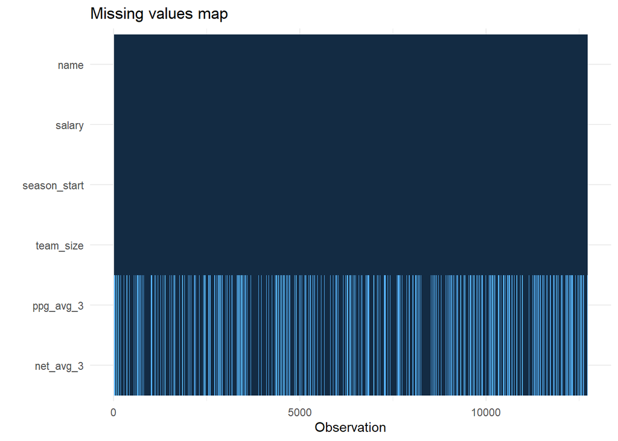

```r
#select only the columns we need as predictors and responses
NBA_salary = NBA_salary %>%
  select(name, salary, season_start, team_size, ppg_avg_3, net_avg_3)

#plot missing values
NBA_salary %>%
  missing_plot()
```

From the missing values map, we know, from previous description, that the years where data is collected didn’t perfectly match in the salary and player info data set. The missing values is due to the mismatch of timeframes, and since the observations without the missing values is still a large number, we can go on and just drop the rows with NA values.

```r
#drop rows with na values
NBA_salary = NBA_salary %>%
  drop_na()

#check the number of observations of NBA_salary
nrow(NBA_salary)
```

```
## [1] 8989
```

We still have 8989 observations, which is enough for a linear regression model. After all the data cleaning and tidying, we finally built the data set with parameters that we’re interested in.

### Describing the Predictors

Now that we have cleaned up and obtain the data set we needed, let’s introduce the desciption of these variables before we go to the next step:

- `name`: The name of the NBA player (ex. Lebron James, Kobe Bryant)
- `salary`: The salary of the NBA player given the year he played in
- `season_start`: The calander year when the season started (ranging from 1996 to 2018)
- `team_size`: The market size of the NBA team based on the city located (either big, mudium or small)
- `ppg_avg_3`: The averge points per game of the player’s past three years’ performance. If the player only has one or two previous years’ data, then take the average of those years. If the player has no prior years of data, then take the current year’s points per game.
- `net_avg_3`: Team’s point differential per 100 possessions while the player is on the court. Miving average calculated the same way as `ppg_avg_3`

We’ve defined all the variables in our data set. Moving forward, we’re going to do some exploratory data analysis and take a deeper look comprehensively about our data.

## Visual EDA

A few question arose automaticallyupon gethering this data set, I want to explore the data set to an extent by making some graphs and just to see the general trend and the distribution of my estimand along with some estimators.

### Salary Distribution

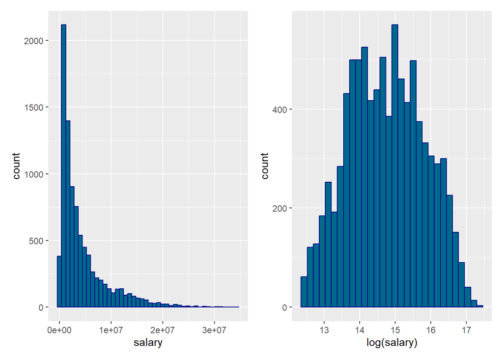

```r
#check the distribution of salary
salary_graph = NBA_salary %>%
  ggplot(aes(x = salary)) +
  geom_histogram(binwidth = 800000, fill = "deepskyblue4", color = "darkblue")

#check the distribution of log(salary)
salary_graph_log = NBA_salary %>%
  ggplot(aes(x = log(salary))) +
  geom_histogram(fill = "deepskyblue4", color = "darkblue")

#compare two graphs
salary_graph + salary_graph_log
```

Observe that the distribution of `salary` is highly skewwed to the right, and when we take the log values, the distribution look more like a normal curve than before we transformed it.

### 3 Year Points per Game Distribution

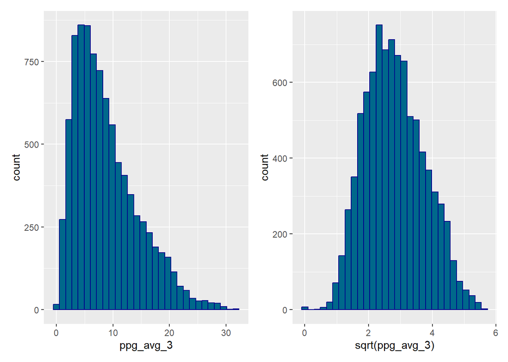

```r
#check the distribution of ppg_avg_3
ppg_graph = NBA_salary %>%
  ggplot(aes(x = ppg_avg_3)) +
  geom_histogram(fill = "deepskyblue4", color = "darkblue")

#check the distribution of sqrt(ppg_avg_3)
ppg_graph_sqrt = NBA_salary %>%
  ggplot(aes(x = sqrt(ppg_avg_3))) +
  geom_histogram(fill = "deepskyblue4", color = "darkblue")

#compare two graphs
ppg_graph + ppg_graph_sqrt
```

We have a similar obervation, the distribution of `ppg_avg_3` is also highly skewed to the right, when we take the square root value of it, the distribution looks more like a normal distribution. This could be a hint of the post fitting analysis and maybe we would need to apply these transformation to better fit the linear model later on.

### 3 Year Net Rating Distribution

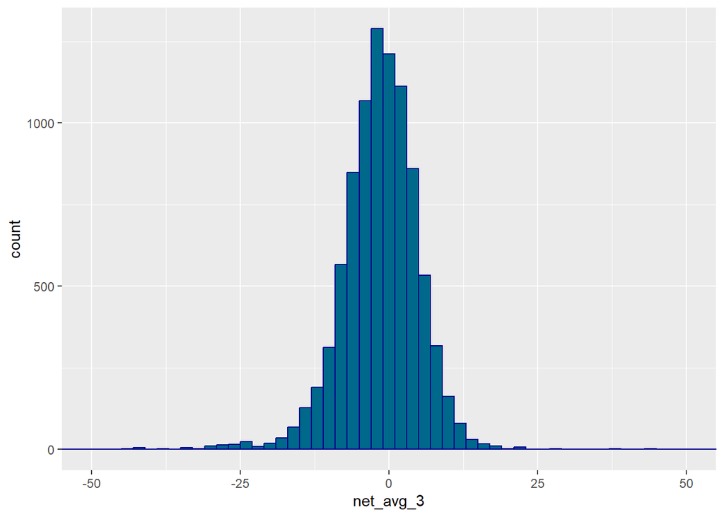

```r
#check the distribution of net_avg_3
NBA_salary %>%
  ggplot(aes(x = net_avg_3)) +
  geom_histogram(binwidth = 2,fill = "deepskyblue4", color = "darkblue") +
  coord_cartesian(xlim = c(-50, 50))
```

Observe that the predictor `net_avg_3` is approximately normally distributed, with mean close to zero.

### Correlation Between Numeric Variables

We will investigate the correlation of different variables by looking at dot plots as well as the variable correlation plot. First, let’s take a look at the dot plot of the relation of different predictors and the response, see if we can recognize any trend or pattern visually.

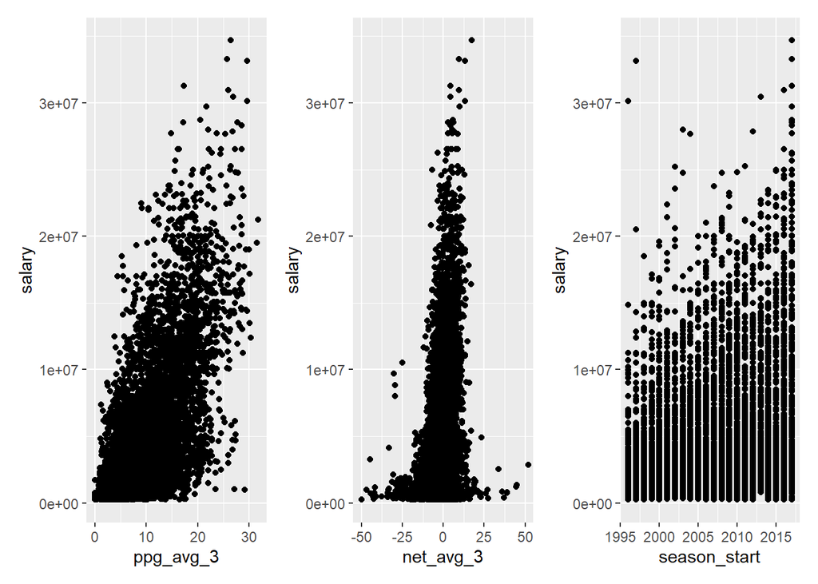

```r
#create the dot plot of salary and ppg_avg_3
salary_ppg_avg_3 = NBA_salary %>%
  ggplot(aes(x = ppg_avg_3, y = salary)) +
  geom_point()

#create the dot plot of salary and net_avg_3
salary_net_avg_3 = NBA_salary %>%
  ggplot(aes(x = net_avg_3, y = salary)) +
  geom_point() +
  coord_cartesian(xlim = c(-50, 50))

#create the dot plot of salary and season_start
salary_season_start = NBA_salary %>%
  ggplot(aes(x = season_start, y = salary)) +
  geom_point()

salary_ppg_avg_3 + salary_net_avg_3 + salary_season_start
```

From the graphs, we can see a clear positive trend and correlation between a player’s previous three years ppg and his salary, as well as the year he plays in and the salary he makes. As for the relation between the players net rating and his salary, the correlation is not self explanatory so we would need some further explanation. Now, let’s look at the variable correlation plot.

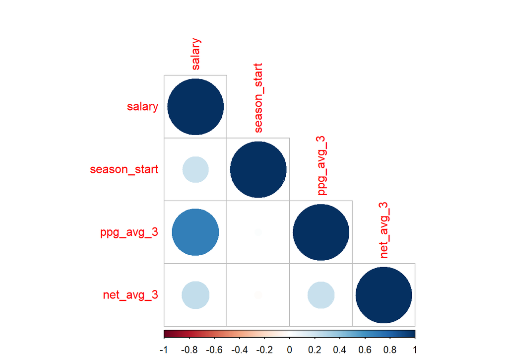

```r
#take only the numeric columns from NBA_salary
numeric_NBA_salary = NBA_salary %>% select_if(is.numeric)

#compute the correlation matrix
correlation_matrix = cor(numeric_NBA_salary)

#plot lower triangle correlation matrix
corrplot(correlation_matrix, type = "lower")
```

From the correlation plot of the numeric variables, we can see that all `season_start`, `ppg_avg_3`, `net_avg_3` are positively correlated with `salary` in different extent, with `ppg_avg_3` having the strongest correlation. There’s also a slight positive correlation between `ppg_avg_3` and `net_avg_3`, which makes sense since, these are both stattistics that are expected to be high from a “good” player.

### Notes on Notible Outliers

```r
filter(NBA_salary, salary > 30000000)
```

```
##             name   salary season_start team_size ppg_avg_3 net_avg_3
## 1    Kobe Bryant 30453805         2013       big  26.83333  4.500000
## 2  Stephen Curry 34682550         2017       big  26.40000 17.500000
## 3   LeBron James 30963450         2016    medium  25.90000  9.566667
## 4   LeBron James 33285709         2017    medium  25.66667  9.500000
## 5 Michael Jordan 30140000         1996       big  29.60000 13.400000
## 6 Michael Jordan 33140000         1997       big  29.60000 13.400000
## 7   Paul Millsap 31269231         2017    medium  17.30000  4.566667
```

What’s worth noting is that in the `season_start` to `salary` graph, there’s two clear outliers in year 1996 and year 1997 earning over 30,000,000 per year, which no players in future years can catch up to such level until 2013. This player, you might have guessed, is also referred as the God of Basketball - Michael Jordan.

### Correlation of Categorical Variable

Next, we’re going to visualize the effect of the size of an NBA team have on a player’s salary. To better represent the trend, we’re going to take the log of the salary value in stead of the actual salary, and we’re going to use box plot for easier visualization.

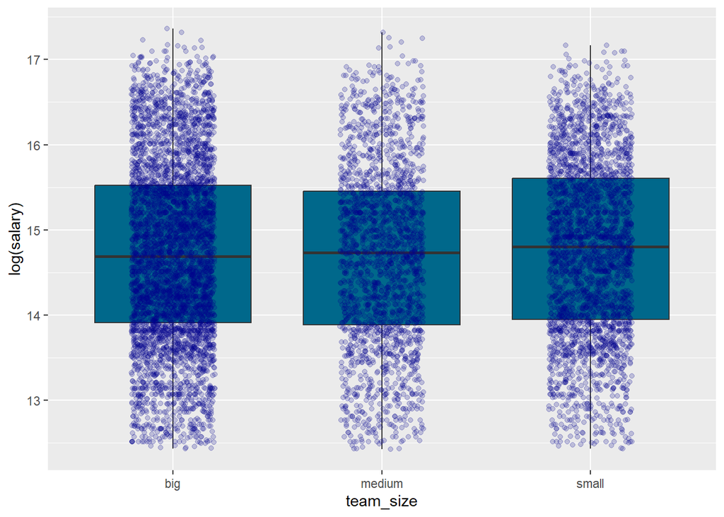

```r
#compare the distribution of salary based on team_size
team_size_salary = NBA_salary %>%
  ggplot(aes(x = as.factor(team_size), y = log(salary))) +
  geom_boxplot(fill = "deepskyblue4") +
  geom_jitter(alpha = .2, color = "darkblue", width = 0.2) +
  labs(x = "team_size")

team_size_salary
```

The differences is unclear visually and it’s hard to tell if a player can earn more by playing for a big, medium, or small team. Therefore, the effect of team size on player’s salary also requires further investigation through model fitting.

## Model Fitting

### Fitting Linear Regression Model

Now, let’s fit our data in a linear regression model. Since the predictor `team_size` is categorical, we first create dummy variables and then use the dummy variables to fit in the model

```r
#drop the name column as it is irrelevant to the purpose of this project
NBA_salary_no_name = NBA_salary %>%
  select(-name)

#create dummy variables
dummy_vars = model.matrix(~ team_size - 1, data = NBA_salary_no_name)  # Exclude intercept term with '- 1'

#combine dummy variables with original data
NBA_salary_with_dummy = NBA_salary_no_name %>%
  cbind(dummy_vars) %>%
  select(-team_size)

#fit linear regression model
lm_NBA_salary = lm(salary ~ ., data = NBA_salary_with_dummy)

#print the summary of the linear model
summary(lm_NBA_salary)
```

```
##
## Call:
## lm(formula = salary ~ ., data = NBA_salary_with_dummy)
##
## Residuals:
##       Min        1Q    Median        3Q       Max
## -14428398  -1907624   -223311   1376709  20427855
##
## Coefficients: (1 not defined because of singularities)
##                   Estimate Std. Error t value Pr(>|t|)
## (Intercept)     -309877915   10926458 -28.360   <2e-16 ***
## season_start        154147       5444  28.316   <2e-16 ***
## ppg_avg_3           558343       6270  89.048   <2e-16 ***
## net_avg_3            54770       4318  12.685   <2e-16 ***
## team_sizebig        -16188      78849  -0.205    0.837
## team_sizemedium    -103578      95113  -1.089    0.276
## team_sizesmall          NA         NA      NA       NA
## ---
## Signif. codes:  0 '***' 0.001 '**' 0.01 '*' 0.05 '.' 0.1 ' ' 1
##
## Residual standard error: 3223000 on 8983 degrees of freedom
## Multiple R-squared:  0.5254, Adjusted R-squared:  0.5251
## F-statistic:  1989 on 5 and 8983 DF,  p-value: < 2.2e-16
```

From the summary of our linear model, observe and conclude that `season_start`, `ppg_avg_3`, `net_avg_3` all have significant positive effect on a players annual salary. In short, the if a player is more recent, scores more, or have a great net rating, they are expected to have more income than those that fall short in these predictor variables. However, the market size of the team, `team_size`, doesn’t play as big of a role in deciding a players wage and it’s effect is not significant.

### Analyze with Linear Transformation of Variables

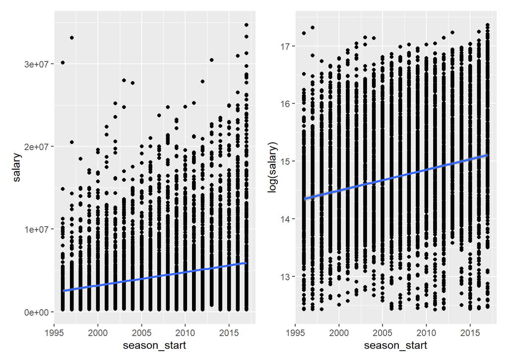

```r
#salary vs season_start regression
salary_season_start = NBA_salary_with_dummy %>%
  ggplot(aes(x = season_start, y = salary)) +
  geom_point() +
  geom_smooth(method = "lm")

#log(salary) vs season_start
salary_season_start_trans = NBA_salary_with_dummy %>%
  ggplot(aes(x = season_start, y = log(salary))) +
  geom_point() +
  geom_smooth(method = "lm")

#compare the two graph
salary_season_start + salary_season_start_trans
```

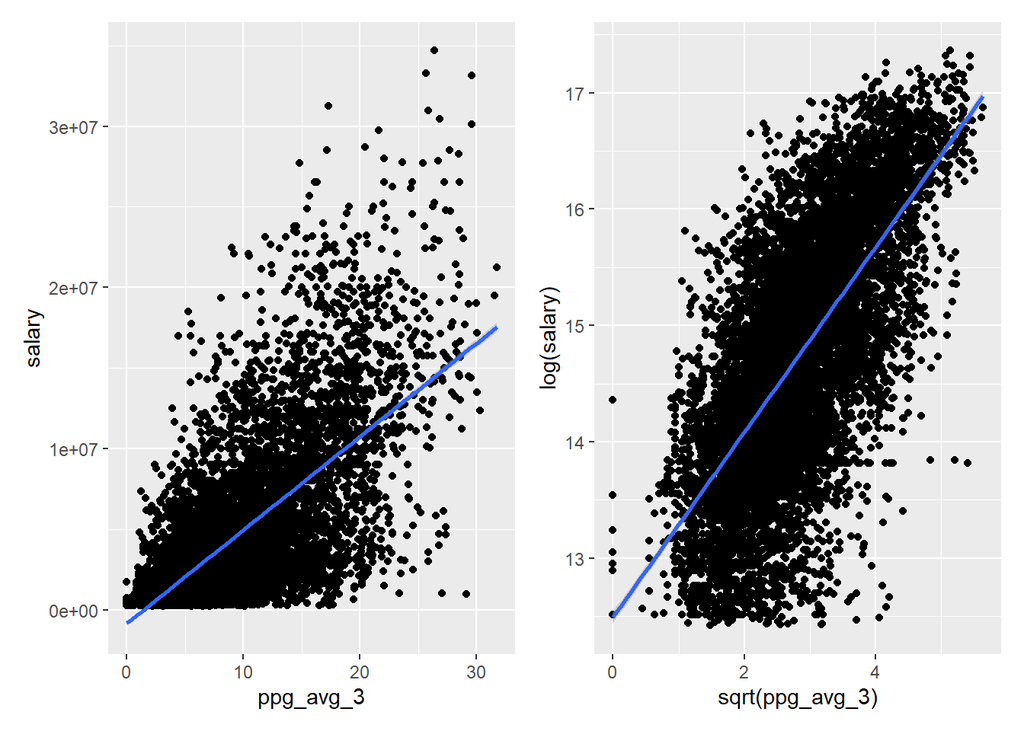

```r
#salary vs ppg_avg_3 regression
salary_ppg = NBA_salary_with_dummy %>%
  ggplot(aes(x = ppg_avg_3, y = salary)) +
  geom_point() +
  geom_smooth(method = "lm")

#log(salary) vs sqrt(ppg_avg_3) regression
salary_ppg_trans = NBA_salary_with_dummy %>%
  ggplot(aes(x = sqrt(ppg_avg_3), y = log(salary))) +
  geom_point() +
  geom_smooth(method = "lm")

#compare the two graph
salary_ppg + salary_ppg_trans
```

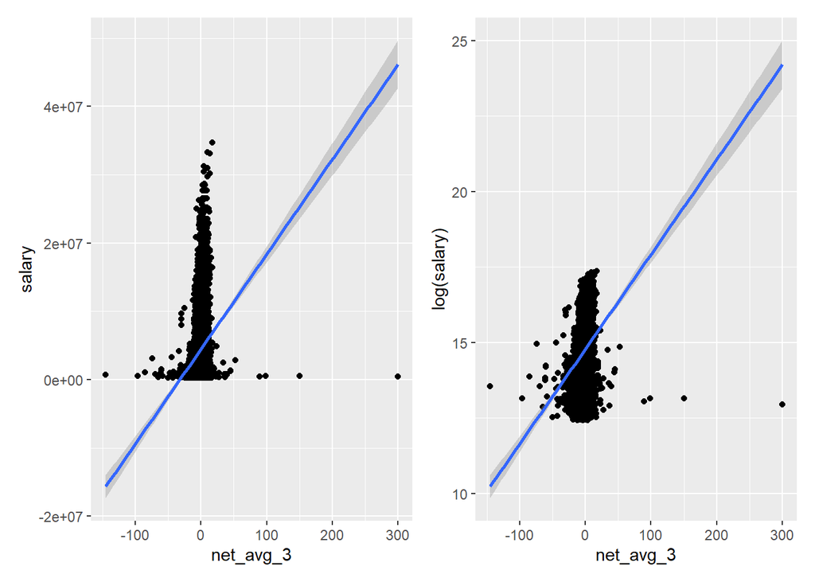

```r
#salary vs net_avg_3 regression
salary_net = NBA_salary_with_dummy %>%
  ggplot(aes(x = net_avg_3, y = salary)) +
  geom_point() +
  geom_smooth(method = "lm")

#log(salary) vs net_avg_3 regression
salary_net_trans = NBA_salary_with_dummy %>%
  ggplot(aes(x = net_avg_3, y = log(salary))) +
  geom_point() +
  geom_smooth(method = "lm")

#compare the two graph
salary_net + salary_net_trans
```

For the variables that are significant predictors, I’ve created visualization and comparison of the case if we fit regression with raw data and the case when we take the log value and some linear transformation of the predictors (particularly, taking square root of `ppg_avg_3`). We can see that, for predictors `season_start` and `ppg_avg_3`, after the transformation, linear regression seemed to be a pretty good predicting model. But for predictor `net_avg_3`, maybe we need some other transformation to better fit the linear transformation model, or perhaps we should use other type of models.

Now lets look at the residuals and fitted values plot

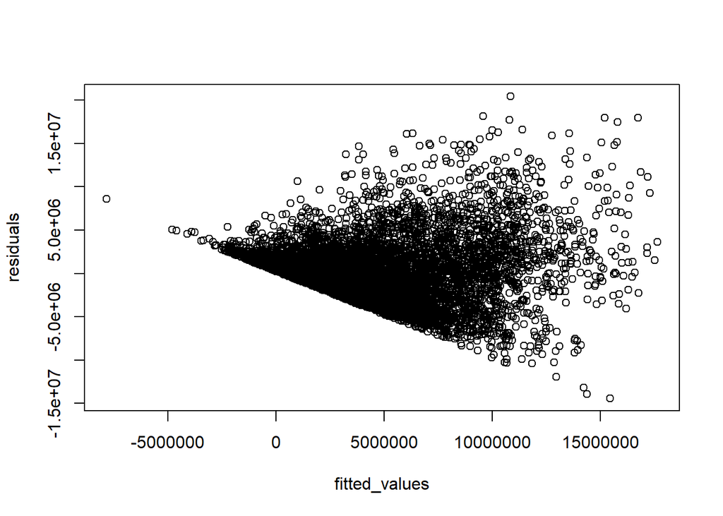

```r
#residuals and fitted values plot
residuals = residuals(lm_NBA_salary)
fitted_values = fitted(lm_NBA_salary)

plot(fitted_values, residuals)
```

This is not a perfect shape of a residual plot as there is clear trend and lack of randomness of the residual plot. Form what the previous sections suggested, a useful solution can be taking log of the `salary` values. Furthermore, since taking the square root of `ppg_avg_3` gives a shape closer to a normal distribution, we will take the square root of the `ppg_avg_3` predictor as well. In the next section, we will try to fit the linear regression model again, but after linear transformations of variables.

### Fitting Linear Regression Model with Linear-Transformed Variables

```r
#taking the square root of ppg_avg_3 and replace the original variable
NBA_salary_with_dummy = NBA_salary_with_dummy %>%
  mutate(sqrt_ppg_avg_3 = sqrt(ppg_avg_3)) %>%
  select(-ppg_avg_3)

#fit linear regression model with logarithmic transformed response
lm_NBA_salary_log = lm(log(salary) ~ ., data = NBA_salary_with_dummy)

#print the summary of the linear model
summary(lm_NBA_salary_log)
```

```
##
## Call:
## lm(formula = log(salary) ~ ., data = NBA_salary_with_dummy)
##
## Residuals:
##     Min      1Q  Median      3Q     Max
## -3.5291 -0.4788  0.0467  0.5080  2.4321
##
## Coefficients: (1 not defined because of singularities)
##                   Estimate Std. Error t value Pr(>|t|)
## (Intercept)     -5.411e+01  2.495e+00 -21.685  < 2e-16 ***
## season_start     3.326e-02  1.244e-03  26.745  < 2e-16 ***
## net_avg_3        1.142e-02  9.879e-04  11.556  < 2e-16 ***
## team_sizebig    -5.020e-02  1.800e-02  -2.788  0.00531 **
## team_sizemedium -6.350e-02  2.172e-02  -2.924  0.00347 **
## team_sizesmall          NA         NA      NA       NA
## sqrt_ppg_avg_3   7.665e-01  8.625e-03  88.871  < 2e-16 ***
## ---
## Signif. codes:  0 '***' 0.001 '**' 0.01 '*' 0.05 '.' 0.1 ' ' 1
##
## Residual standard error: 0.736 on 8983 degrees of freedom
## Multiple R-squared:  0.5233, Adjusted R-squared:  0.5231
## F-statistic:  1972 on 5 and 8983 DF,  p-value: < 2.2e-16
```

### Check for Assumptions

In the last step of this project, we want to check the characteristics of our residuals to see if they match the assumptions of linear regressions. Particularly, we want to check the normality and homoscedasticity of residuals. First, we create the Q-Q plot to check for normality

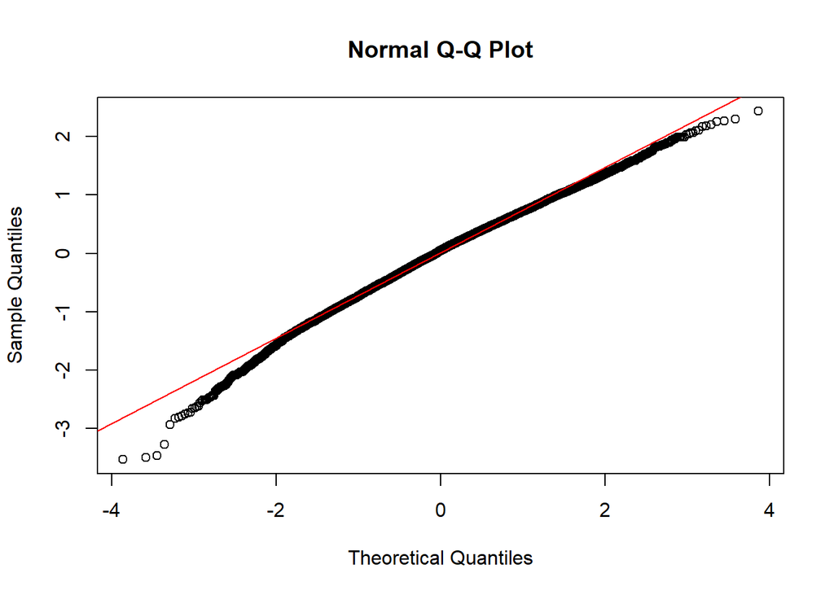

```r
#create the qqplot for the residuals
residuals = residuals(lm_NBA_salary_log)

qqnorm(residuals)
qqline(residuals, col = "red")
```

Even though the points don’t perfectly follow the line on both ends, the general trend of the dotted line does follow the qqline, suggesting that the residuals are normally distributed, we can also look at the histogram to see the distribution of the residuals.

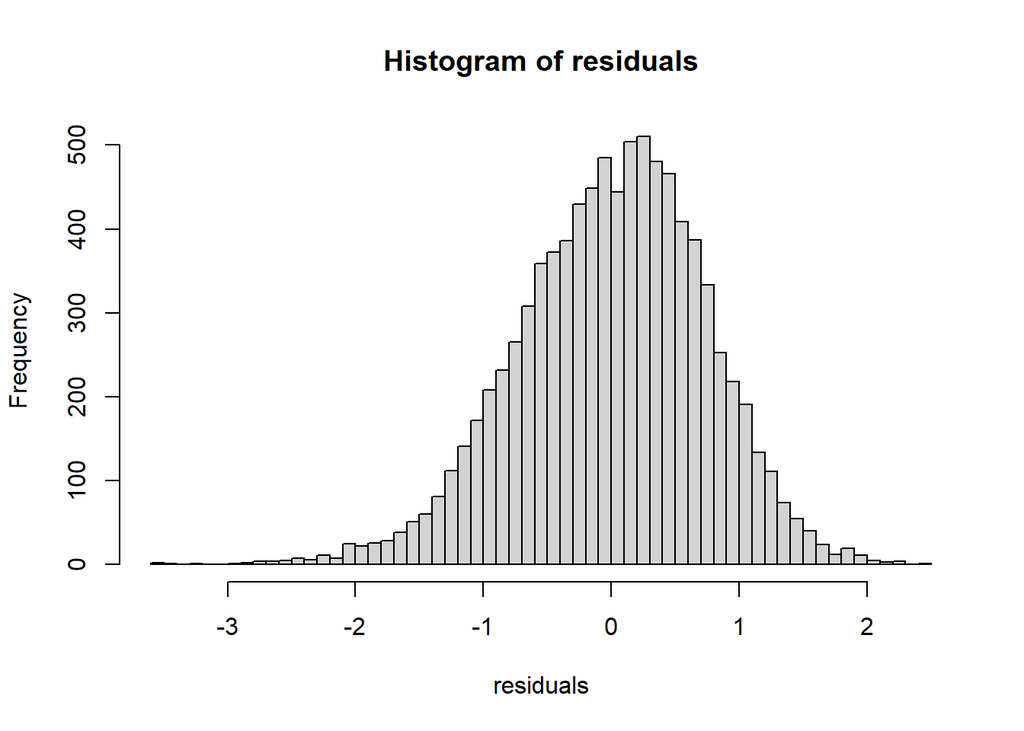

```r
hist(residuals, breaks = 50)
```

The histogram is a bell shaped curve, matching our initial conclusion, which is the residuals are normally distributed. Next, let’s revisit the residual plot after linear transformation of variables and check for homoscedasticity.

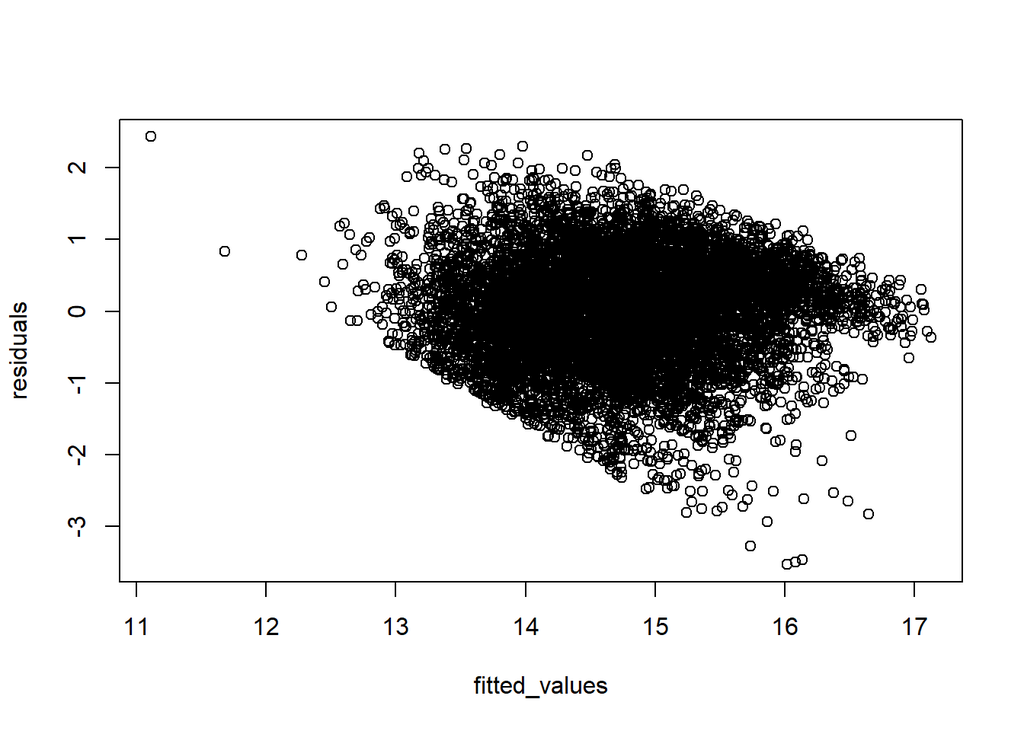

```r
#residuals and fitted values plot
fitted_values = fitted(lm_NBA_salary_log)

plot(fitted_values, residuals)
```

The residual plot after the transformations definitely looks better than before the transformation is applied, but it still seems like there’s a trend in the residual plot, which for residuals to be homoscedastic the residual plot should be scattered without a recognizable trend. This suggests that further actions and investigations are needed, perhaps with a different transformation of variable or with a different model. Due to the scope and the purpose of this project, we will stop here until more advanced tools are provided in the future to better explain the data.

## Conclusions

The purpose of this project is to showcase data mining, data cleaning and tidying, as well as model fitting and analysis of the linear regression model. I understand that to better analyze my data, I would need to try out more models to see if they explain the trend better. Hopefully, I can get back to this data set in the near future after I learn about more models and data analysis skills.

Throughout this project, I have gotten familiar with dealing with complicated databases. I have gathered data from multiples sources based on the initial hypothesis I had in mind, and I had successfully found the data sets that can support my beliefs statistically. I’ve combined data sets and created variables and predictors of interest based on the resources I have. I’ve also researched, explored, and analyzed the data frame regarding to an NBA player’s earnings based on multiple predictors.

To summarize my findings, I have proven that, for an NBA player, based on data from 1996-2018, the year a player plays in, their points per game for previous three years, and their net rating average for previous three years, all play a significant indicator in prediction of a player’s salary in the corresponding year. Surprisingly, the market size of the team also plays as an significant factor in deciding a player’s salary, but in stead of the order I imagined, which is big > medium > small, the model suggest that the order from most to least amount of salary is actually small > big > medium.